# Data Structures in Python

## Data types

Python supports many data types. Some of them are common among other programming languages and some of them are native to Python. The list of data types is given in the picture below, and we discuss all the data types in detail, throughout this notebook.

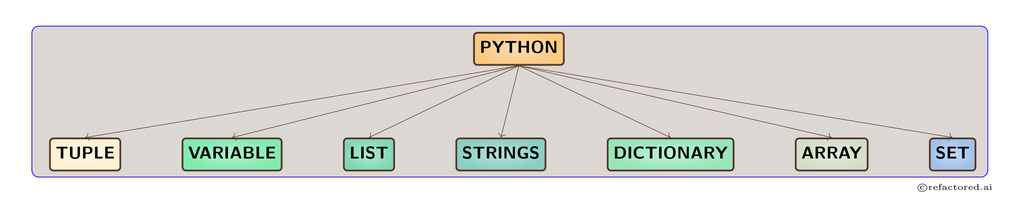

### Initializing Variables

Python variables do not need declaration or specification of data type. For example,

```
a = 5
b = 5.0
c = "string"
```

are all correct assignments.

The same value can be assigned to multiple variables in a sequence as shown below unlike many other languages which allow single variable assignment.

```
a = b = c = 5
```

**Let us begin coding with our first exercise.**

### Exercise

Initialize and print

- a) an integer variable (x) with value 4
- b) a floating point variable (y) with value 6.78
- c) a string variable (z) with value 'Hello'
- d) re-assign all three variables with a string 'I love python' and print all three variables.

The objective of this task is to show the ease of re-assigning a variable in python. The variable does not need to be typecasted and python automatically assigns the data type to the variable based on the value it is assigned. (i.e., If x='Hello', then 'x' is automatically identified by python as a string variable. If 'x' is re-assigned a value of 12.6, say x=12.6, then 'x' is automatically identified as a float)

```python
# Initialize the variables
# Please make sure you use the variables x,y,z only to do your exercise and pass the exercise. If you use other variables, you might not get right results.
```

## Solution

```
x = 4
y = 6.78
z = 'Hello'

print (x, y, z)

# Re-assigning all three variables
x = y = z = 'I love python'
print (x, y, z)
```

### Format specifiers in Python

When you want to put a placeholder for a variable and pass the value to the function separately, we can use something called format specifier. This is typically a set of symbols which tell the function about the format in which the value being passed is to be printed. Format specifiers for various types of data types in Python are similar to other programming languages:

- %d for integer
- %f for float
- %s for string
- %r for raw object using 'repr' method
- %x for hex code

We can use the format specifiers as placeholders in a print statement, and pass the value of a specific variable using the '%' operator. Multiple variables/values can also be passed by enclosing all variables in paranthesis and separating them by commas.

An example:

```
a = 10
b = 5

print("I want to print %d and %d in the same sentence"%(a,b))

# Output
>>> I want to print 10 and 5 in the same sentence
```

Another example:

```
a = 10.264725
b = "a string type"

print("I want to print %f and %s in the same sentence"%(a,b))

# Output
>>> I want to print 10.264725 and a string type in the same sentence
```

Alternative to the '%' operator, we have the format() function which can also be used.

```
a = 10
b = 5

print("I want to print {:d} and {:d} in the same sentence".format(a,b))

# Output
>>> I want to print 10 and 5 in the same sentence
```

```
a = 10.264725
b = "a string type"

print("I want to print {:f} and {:s} in the same sentence".format(a,b))

# Output
>>> I want to print 10.264725 and a string type in the same sentence
```

#### Rounding off a float and adding preceeding zeroes

In the above example, where we had a float value, we may want to restrict the number of decimals and print a rounded value. On the other hand we may want to add a preceeding zero to the number, in case the value a here is a single observation in a larger pool of numbers which have 3 digits before the decimal. We can add preceeding zeroes and round off float values by specifying the type of formatting for a float, after the '%' symbol and before the 'f' symbol of the format specifier.

- Use a period symbol ('.') to denote the decimal in the float value
- For preceeding zeroes, add total desired length of the number (including decimal point), in digits, before the period symbol. And before this number, add a '0' to denote that all preceeding blank spaces need to be filled with zeroes.
- For rounding off decimals, add the number up to which you want decimals, right after the period symbol and before the 'f' symbol

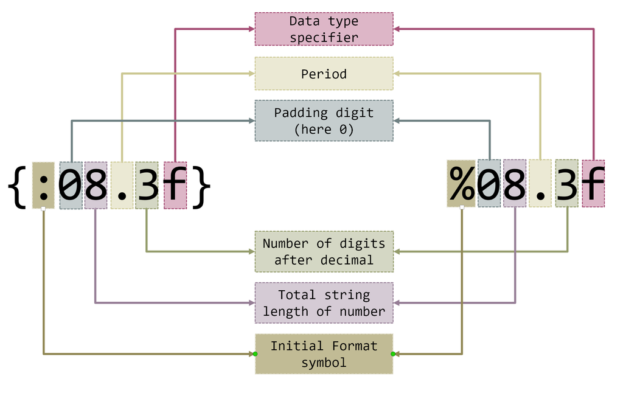

A few examples:

```
a = 10.264725

print('''Variations of a floating point:
1. {:.2f}
2. {:.3f}
3. {:4.4f}
4. {:04.4f}
5. {:8.4f}
6. {:08.4f}
7. {:010.4f}'''.format(a,a,a,a,a,a,a))

# Output
>>> Variations of a floating point:
>>> 1. 10.26
>>> 2. 10.265
>>> 3. 10.2647
>>> 4. 10.2647
>>> 5.  10.2647
>>> 6. 010.2647
>>> 7. 00010.2647
```

**Important note:** In above example '{:4.4f}' and '{04.4f}' give the same output, where we cannot see any padding (neither blanks nor zeroes). This is because the length that we specified for the string is 4, whereas we have also asked for 4 digits after the decimal point. So the digits after decimal take precedence and these 4 digits are added first. Then the whole number is generated - the characteristic (digits before decimal) and the mantissa (digits after the decimal). After this the control checks to add padding. It now finds that the condition for length of number we have specified is 4, and the length of number is already more than 4, hence it does not add any padding blanks or zeroes.

For more details on formatting refer to: https://pyformat.info/

#### Exercise

Given variables -

- a = 5
- b = 134.264262
- c = "Hello! How are you?"

Print the following using appropriate format specifiers

- the integer and a floating point equivalent of a
- the value of b, upto one decimal place and padded with two preceeding zeroes
- the string c, truncated up to first 10 characters

### Solution code

```
a = 5
b = 134.264262
c = "Hello! How are you?"

print('''The answers are:
1. {:d} and {:f}
2. {:07.1f}
3. {:.10s}'''.format(a,a,b,c))
```

## Variable Operators

Operators are the constructs which can manipulate the value of operands/variables.

### Arithmetic Operators

The standard arithmetic operators in Python are:

- + for addition - Adds the values of two variables
- - for subtraction - Subtracts the value of right hand side variable from left hand side variable
- * for multiplication - Multiplies the values of two variables with each other
- / for division - Divides the value of left hand side variable (called Dividend) with the value of right hand side variable (called Divisor) and returns 'Quotient'
- ** for exponentials - Exponential, multiplies the number on the left hand side with itself, the number of times equal to the the right hand side value
- % for modulus - Modulus, similar to division operator, but returns the remainder of the division, rather than the quotient

A few examples to understand output of each arithmetic operator:

```
# Importing numpy library to create n-dimensional arrays for matrix multiplication. We will learn more about this later
import numpy as np

# Creating simple variables
a = 10
b = 5

# Creating arrays for matrix multiplication
c = np.array([[1,2,3],[4,5,6]])
d = np.array([[1,0,0],[0,1,0],[0,0,1]]) # This is identity matrix. We will learn about this in Math module

# Simple operations
sum_ab = a + b
diff_ab = a - b
prod_ab = a*b
div_ab = a/b
rem_ab = a%b
exp_ab = a**b

# Matrix multiplication
mat_mul = c@d

print('''The sum of a and b is: %.2f
The difference of a and b is: %.2f
The product of a and b is: %.2f
The quotient of a divided by b is: %.2f
The remainder of a divided by b is: %.2f
The exponential of a to the power of b is: %.2f
The matrix product of a and b is:'''%(sum_ab,diff_ab,prod_ab,div_ab,rem_ab,exp_ab),mat_mul)

# Output
>>> The sum of a and b is: 15.00
>>> The difference of a and b is: 5.00
>>> The product of a and b is: 50.00
>>> The quotient of a divided by b is: 2.00
>>> The remainder of a divided by b is: 0.00
>>> The exponential of a to the power of b is: 100000.00
>>> The matrix product of a and b is: [[1 2 3]
>>> [4 5 6]]
```

As the name suggests, the arithmetic operators generally support numeric value operations with the exception of '+', which works as concatenation in case of string values. Table of supported data structures:

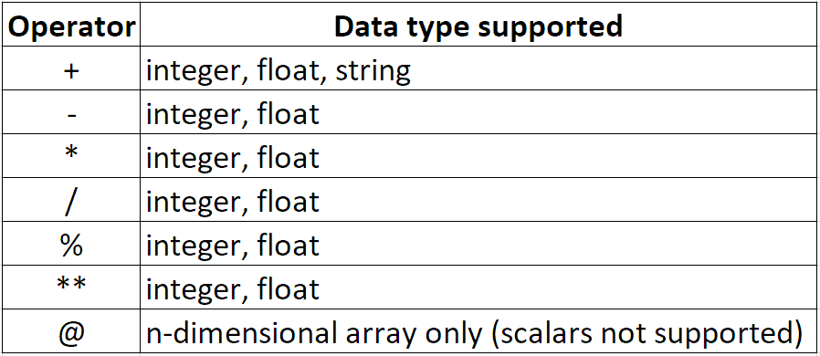

### Relational/Comparison Operators

The comparison operators are similar to most other programming languages with the commonly known symbols:

- > for greater than
- < for less than
- = for assignment
- == for equal to
- >= for greater than or equal to
- <= for less than or equal to
- != for not equal to

The relational/comparison operators are generally used to compare numeric values (integer and float). Though output may be generated while using character data types, it is often unexpected and irrational.

The operators return a boolean value 'True' or 'False', which can also be presented numerically as 1 for True and 0 for False.

An example:

```
# Creating simple variables
a = 10
b = 5

# Simple operations
greater_ab = a>b
lesser_ab = a<b
gr_or_eq_ab = a>=b
le_or_eq_ab = a<=b
eq_to_ab = a==b
not_eq_to_ab = a!=b

print('''Is a greater than b: %r
Is a less than b: %r
Is a greater than or equal to b: %r
Is a less than or equal to b: %r
Is a equal to b: %r
Is a not equal to b: %r'''%(greater_ab,lesser_ab,gr_or_eq_ab,le_or_eq_ab,eq_to_ab,not_eq_to_ab))

#Output
>>> Is a greater than b: True
>>> Is a less than b: False
>>> Is a greater than or equal to b: True
>>> Is a less than or equal to b: False
>>> Is a equal to b: False
>>> Is a not equal to b: True
```

Another example:

[output not shown]

### Exercise

Given a=34 and b=57, verify the following conditions:

- Is the total of a and b equal to b?
- Is the total of a and b greater than a?
- Is the total of a and 23 less than or equal to b?
- Is the total of a and 23 equal to a?
- Is the product of a and 18, divided by 18 is not equal to a itself?

[output not shown]

### Solution code

```
a = 34
b = 57

ans = a + b
cond_1 = ans == b
cond_2 = ans > a

ans = a + 23
cond_3 = ans <= b
cond_4 = ans == a

ans = a * 18
cond_5 = (ans/18) != a

print('cond_1: {}'.format(cond_1))
print('cond_2: {}'.format(cond_2))
print('cond_3: {}'.format(cond_3))
print('cond_4: {}'.format(cond_4))
print('cond_5: {}'.format(cond_5))
```

### Bitwise Operators

Bitwise operators or logical operators are very common in programming languages. The operators generally take more than one condition and associated variables, process the outputs of all conditions and based on satisfaction of each condition, they generate a final boolean output, based on what logical the specific operator supports. To explain in simpler terms:

Python bitwise operators:

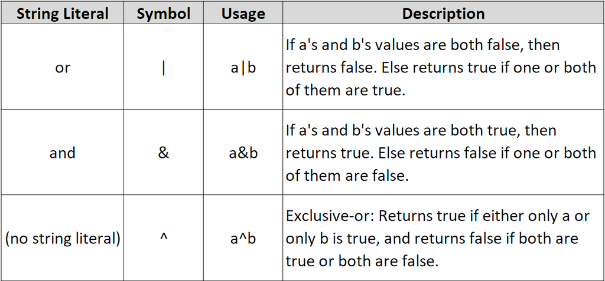

Examples:

```
a = False
b = True

print(a|b,a&b,a^b)
# Output
>>> True False True

print(a or b, a and b)
# Output
>>> True False
```

More examples:

```
print(43>(-35) | 74<14, 79>12 and 625==(25**2), (62>14.2) ^ (626.23<1224))

# Output
>>> True True False
```

#### Exercise

In a chemical factory there two furnaces which are running to produce a special chemical resin. The running of the two furnaces are indicated by two lights 'A' and 'B'. Both A and B can show two colors - green indicating furnace is on, red indicating furnace is off.

- If A is green and B is red, one of the furnace is running and the ideal temperature for resin is maintained.
- If B is green and A is red, one of the furnace is running and the ideal temperature for resin is maintained.
- If both A and B are green, then it is too hot as both furnaces are running, and the resin deforms.
- If both A and B are red, then both furnaces are off, and no resin can be produced.

Use a bitwise operator to model the relationship of A and B lights to indicate whether the furnaces need to be inspected or not. (True - furnaces are running ok, no need of inspection, False - furnaces are not ok, need inspection)

Note that furnaces need to be inspected if resin is not being produced or it is getting deformed. Assume values of lights as:

- A = 'green'
- B = 'red'

Also, note that since there are only two states - green and red, you may encode them as True and False - i.e., True the furnace is running or False the furnace is off.

```python
A = True
B = False
```

[output not shown]

### Solution code

```
print(A^B)
```

### Membership Operator (in)

Python’s membership operators test for membership in a sequence, such as strings, lists, or tuples.

For the code 'x in y', if x is a subset of y, then the result is True:

```
# list
a = [1,2.35,"Hello","cat",114]

# "\n" creates a new line while printing
print(" Is 15 in list a:", 15 in a, "\n", "Is 'cat' in list a:", 'cat' in a, "\n", "Is 'dog' in list a:", 'dog' in a, "\n", "Is 'H' in the word 'Hello':", 'H' in 'Hello', "\n", "Is 'd' in the word 'cat':", 'd' in 'cat')

# Output
>>> Is 15 in list a: False
>>> Is 'cat' in list a: True
>>> Is 'dog' in list a: False
>>> Is 'H' in the word 'Hello': True
>>> Is 'd' in the word 'cat': False
```

The 'in' operator is frequently used as a iterator which runs through every element of a list, tuple or string, while using decision statements or loops. We will see more usage of 'in' when we learn about loops and decision statements.

### Identity Operators (is) and the id() function

In order to check the memory location of a variable in Python, we use the id() function. When we pass a variable as an argument to the id() function, it returns a integer which represents the memory location of the given variable. Identity operators compare the memory locations of two python objects and returns True if they point to the same location. 'is' is such an operator.

Two objects can contain the same value but can be different objects, stored at different memory locations. Here is an example which illustrates the 'is' operator:

```
# Example 1
a = 5
b = 5
c = 5.0

print("Location of a:", id(a), "; Location of b:", id(b), "; Is a same as b:", a is b)
print("Location of a:", id(a), "; Location of c:", id(c), "; Is a same as c:", a is c)
print("Is a equal to b:", a==b, "\n", "Is a equal to c:", a==c)

# Output
>>> Location of a: 10919552 ; Location of b: 10919552 ; Is a same as b: True
>>> Location of a: 10919552 ; Location of c: 140045356024168 ; Is a same as c: False
>>> Is a equal to b: True
>>> Is a equal to c: True

# Example 2
a = 'This '
b = a + 'is a python tutorial'
c = 'This is a python tutorial'

b == c
>>> True
b is c
>>> False
```

**Note:** In above example we can see that when we initialized two variables 'a' and 'b' within the same block with the same value, they were both pointing to the same location. Python saves memory in this way, by referring to the same object, when values are same, instead of creating a new object. When some operations are performed on 'a' and 'b' they take up different values and that is when the memory location they reference would change based on which value they would be taking.

```
# Example 3
a = 5
b = 5
c = 5

# Before operating on a,b and c
print("Location of a:", id(a), "; Location of b:", id(b), "; Is a same as b:", a is b)
print("Location of a:", id(a), "; Location of c:", id(c), "; Is a same as c:", a is c)

# Manipulating a,b and c
a = 2*a
b = 2*b
c = 3*c

# After operating on a,b and c
print("Location of a:", id(a), "; Location of b:", id(b), "; Is a same as b:", a is b)
print("Location of a:", id(a), "; Location of c:", id(c), "; Is a same as c:", a is c)

# Output
>>> Location of a: 10919552 ; Location of b: 10919552 ; Is a same as b: True
>>> Location of a: 10919552 ; Location of c: 10919552 ; Is a same as c: True
>>> Location of a: 10919712 ; Location of b: 10919712 ; Is a same as b: True
>>> Location of a: 10919712 ; Location of c: 10919872 ; Is a same as c: False
```

For more on operators, refer to: https://docs.python.org/3/library/operator.html

#### Exercise

Given two variables - a="Hello" and b="Hello"

- Check if a is in b, i.e., is 'a' a subset of 'b'
- Check if a is equal to b. Also check if a is same as b, using the 'is' operator
- Verify above result by comparing the memory locations of a and b using the id() function

### Solution

```
a = "Hello"
b = "Hello"

print("Is a in b:", a in b, "\n", "Is a equal to b:", a==b, "\n", "Is a same as b:", a is b)
print("Location of a:", id(a), "; Location of b:", id(b), "; Do a and b have same location:", id(a)==id(b))
```